# The reproducible research assignmnent

Read to object mydata and format the dates

```r
mydata <- read.csv("activity.csv", sep=",")
mydata$date <- as.Date(mydata$date, format="%m/%d/%Y")
```

The total number of steps taken per day

```r
sumstepsbyday <- by(mydata[, 1], mydata$date, sum, na.rm=TRUE)
sumstepsbyday
```

```
## mydata$date: 2012-10-01
## [1] 0
## --------------------------------------------------------
## mydata$date: 2012-10-02
## [1] 126
## --------------------------------------------------------
## mydata$date: 2012-10-03
## [1] 11352
## --------------------------------------------------------
## mydata$date: 2012-10-04
## [1] 12116
## --------------------------------------------------------
## mydata$date: 2012-10-05
## [1] 13294
## --------------------------------------------------------
## mydata$date: 2012-10-06
## [1] 15420
## --------------------------------------------------------
## mydata$date: 2012-10-07
## [1] 11015
## --------------------------------------------------------
## mydata$date: 2012-10-08
## [1] 0
## --------------------------------------------------------
## mydata$date: 2012-10-09
## [1] 12811
## --------------------------------------------------------
## mydata$date: 2012-10-10
## [1] 9900
## --------------------------------------------------------
## mydata$date: 2012-10-11
## [1] 10304
## --------------------------------------------------------
## mydata$date: 2012-10-12
## [1] 17382
## --------------------------------------------------------
## mydata$date: 2012-10-13
## [1] 12426
## --------------------------------------------------------
## mydata$date: 2012-10-14
```

[output cut: 127 more lines]

```
## --------------------------------------------------------
## mydata$date: 2012-11-26
## [1] 11162
## --------------------------------------------------------
## mydata$date: 2012-11-27
## [1] 13646
## --------------------------------------------------------
## mydata$date: 2012-11-28
## [1] 10183
## --------------------------------------------------------
## mydata$date: 2012-11-29
## [1] 7047
## --------------------------------------------------------
## mydata$date: 2012-11-30
## [1] 0
```

Histogram of the number of steps taken each day

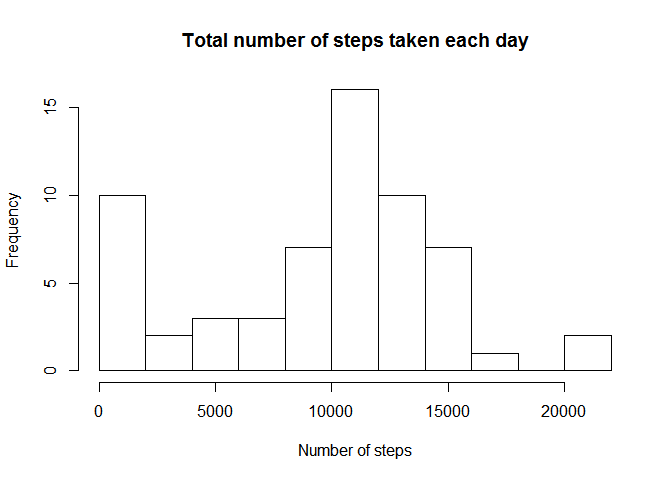

```r
hist(sumstepsbyday, main ="Total number of steps taken each day", xlab="Number of steps", ylab="Frequency", breaks=10)
```

The mean and median of total number of steps taken each day

```r
sumstepbyday1 <- by(mydata[, 1], mydata$date, sum)
meanstepsbyday <- mean(sumstepbyday1, na.rm=TRUE)
meanstepsbyday
```

```
## [1] 10766.19
```

```r
medianstepsbyday <- median(sumstepbyday1, na.rm=TRUE)
medianstepsbyday
```

```
## [1] 10765
```

Calculate and plot the average daily activity pattern

```r
avgsteachintv <- by(mydata[, 1], mydata$interval, mean, na.rm=TRUE)
mydata$interval <- as.factor(mydata$interval)
```

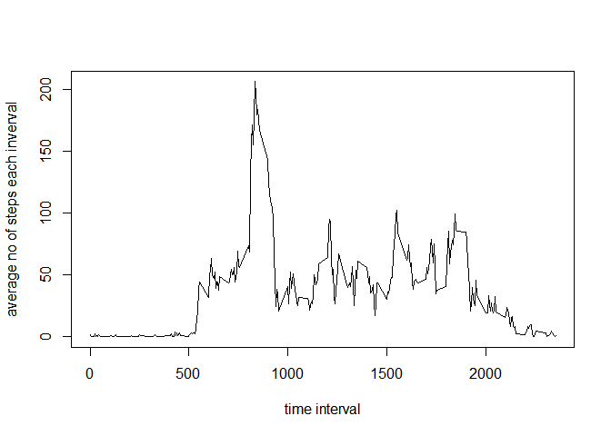

```r
plot(levels(mydata$interval), avgsteachintv,type="l", xlab="time interval", ylab="average no of steps each inverval")
```

Determine the 5-minute interval, on average across all the days in the dataset, contains the maximum number of steps

```r
maxsteps <- max(avgsteachintv)
x <- levels(mydata$interval)
x[which(avgsteachintv == maxsteps)]
```

```
## [1] "835"
```

Calculate and report the total number of missing values, i.e., NAs

```r
sum(is.na(mydata))
```

```
## [1] 2304
```

Imputing the missing values we impute missing values using the mean of the number of steps for that day use the packages Hmisc

calculate the avg number of steps each day

```r
library(Hmisc)
meanstepseachday <- by(mydata[, 1], mydata$date, mean)
```

Create a vector where to copy imputed values

```r
d.impvalues <- vector(mode="double", length=nrow(meanstepseachday))
```

There are some days where no steps are taken. We use zero steps for those days for all the not available data

```r
i <- 1
for (i in 1:nrow(meanstepseachday)) {
    if(is.na(meanstepseachday[i])==F) {
        d.impvalues[i] <- meanstepseachday[i]
        }
    else {
        d.impvalues[i] <- 0
        }
}
```

Create a vector to store all imputable values across all steps in case they are missing (NA)

```r
m.impvalues <- vector(mode="double", length=nrow(mydata))
```

Copy the values for each day across all records of steps taken we first determine the unique number of dates and time interval in the data set

```r
mydata$date <- as.factor(mydata$date)
uniquedates <- length(levels(mydata$date))

uniqueintv <- length(levels(mydata$interval))
```

Copy vales for each day across all records of steps taken

```r
j <- 1
k <- 1
kk <- 1
for (j in 1:uniquedates) {
    for (k in 1:uniqueintv) {
        m.impvalues[kk] <- d.impvalues[j]
        kk <- kk+1
    }
 }
```

Through the original dataset, look for missing values and substitute with the mean for that day. These are contained in the vector [m.impvalues]

```r
jj <- 1
for (jj in 1:nrow(mydata)) {
    if (is.na(mydata$steps[jj])==T) {
        mydata$steps[jj] <- m.impvalues[jj]
        }
}
```

```r
mynewdata <- mydata
```

Check if the new dataset has any missing observations

```r
sum(is.na(mynewdata))
```

```
## [1] 0
```

Histogram of the total number of steps taken each day and Calculate and report the mean and median total number of steps taken per day

```r
sumsteps <- by(mynewdata[, 1], mynewdata$date, sum, na.rm=TRUE)
```

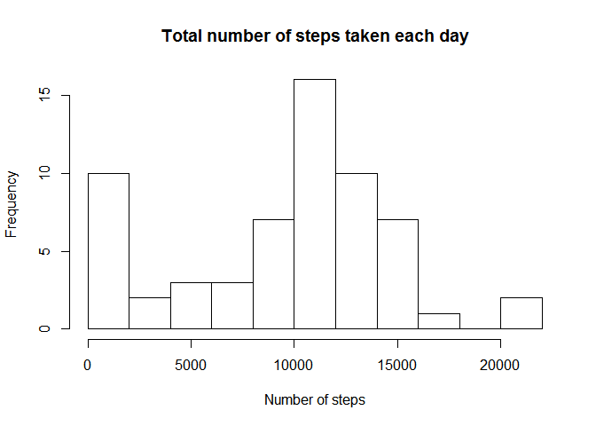

```r
hist(sumsteps, main ="Total number of steps taken each day", xlab="Number of steps", ylab="Frequency", breaks=10)
```

New values of mean and median

```r
mean(sumsteps)
```

```
## [1] 9354.23
```

```r
median(sumsteps)
```

```
## [1] 10395
```

Old values of mean and median

```r
meanstepsbyday
```

```
## [1] 10766.19
```

```r
medianstepsbyday
```

```
## [1] 10765
```

The resuls above show that there is a difference between the mean and median because the imputed values are zero in all cases since for any missing data, it is missing all day and have been substitued for zero. This lowers the mean and median, If a different value, say, for the preceeding or proceeding day had been used, the values would have been higher

Create a new variable. Let us call it : wday Then determine the day of the week for first store in a vector: dayofweek and copy it in each entry and fill it in the newly created column

```r
mynewdata[,4] <- NA
names(mynewdata) <- c("steps", "date", "interval", "wday")

dayofweek <- weekdays(as.POSIXct(mynewdata$date), abbreviate = TRUE)

ii <- 1
for (ii in 1:nrow(mynewdata)) {
    if (dayofweek [ii] == "Sat") {
        mynewdata$wday[ii] <- "weekend"
    }else if (dayofweek [ii] == "Sun") {
        mynewdata$wday[ii] <- "weekend"
    }else {
        mynewdata$wday[ii] <- "weekday"
    }
}
```

Make a panel plot containing a time series plot (i.e. type=“l”) of the 5-minute interval (x-axis) and the average number of steps taken, averaged across all weekday days or weekend days (y-axis). first subset the data and average the steps for weekdays and weekend

```r
wdaydata <- subset(mynewdata, wday == "weekday")
weekenddata <- subset(mynewdata, wday == "weekend")
```

Determine the mean for each and make a plot.

```r
wdaysteps <- by(wdaydata[, 1], wdaydata$interval, mean)
weekendsteps <- by(weekenddata[, 1], weekenddata$interval, mean)
```

Plotting the average number of steps each day for weekdays and weekends for each time interval. The base plot is good enough as per instructions

```r
mynewdata$interval <- as.factor(mynewdata$interval)
```

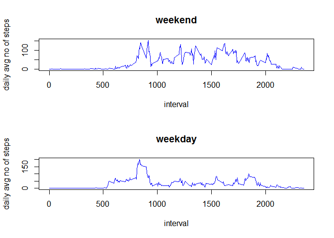

```r
par(mfrow=c(2,1))
plot(levels(mynewdata$interval), weekendsteps, type="l", xlab="interval",ylab="daily avg no of steps",main="weekend",col="blue")
plot(levels(mynewdata$interval), wdaysteps, type="l", xlab="interval",ylab="daily avg no of steps",main="weekday",col="blue")
```